# YimiaoSHE_CASE

## The Dynamic Gravity Dataset 1993-2016

### S04532064

### 2019-6-11

## 壹、前言與背景

```
這一份資料集集描述了國家和地區的各個方面以及它們彼此之間的關係。資料集中的每條記錄由一對國家（地區）和一年定義。資料本身由三種基本類型的變數組成：識別字，單邊特徵和雙邊特徵。

該數據集跨越了1948年至2016年（此分析截取1993-2004和2005-2016年的两份資料集），並通過跟蹤各個國家在此期間發生變化的方式反映了全球的動態特性。生成的資料集涵蓋258個國家和地區，其中一些僅存在於涵蓋年份的子集的資料集中。

選擇這一份資料集，是為了分析全球視角下，國家（地區）之間，尤其是經濟落後區域之間各種變量的關聯性。
```

## 貳、資料來源與說明

```
Dynamic Gravity Dataset 2005-2016，是於美國政府資料平臺（www.data.gov）下載的開放資料，其上架時間為 October 10, 2018 ，其下載網址為：（https://catalog.data.gov/dataset/dynamic-gravity-dataset-1948-2016）

這一份數據描述了1993年至2016年間，258個國家的國家特徵和關係，其資料變項（欄位）包含60多個，描述了宏觀經濟指標、地理特徵、貿易便利化措施、文化關係和體制穩定措施等等。

根據The Dynamic Gravity Dataset: Technical Documentation中的1.2 Variables Included in the Dataset可以了解資料集中各個變量的含義。其地址為：（https://www.usitc.gov/data/gravity/dynamic_gravity_technical_documentation_v1_00_1.pdf）
```

## 參、研究問題

```
本研究的研究問題共有10個：

1.此資料集的基本信息是什麼？
2.屬於經濟較不發達的區域有哪些？(以實際GDP計算）
3.屬於經濟較不發達的區域有哪些？(以人均GDP計算）
4.各國的人口與GDP是否存在相關性？
5.屬於政治穩定度低的區域有哪些？其與經濟發展相對落後的區域是否有所關聯？
6.各區域曾遭受殖民統治的程度為何？其與上述經濟相對落後的區域是否存在關聯？
7,在經濟較不發達的区域，區域內的國家與他國貿易合作的程度是否相對較低？
8.各區域對外合作的主要目標區域有何特點？
9.國家間的距離是否確實影響國家對外的貿易合作傾向？
10.牽涉在較多貿易制裁威脅的區域是哪些？其具有什麼特征？其與上述之分析是否有一定關聯性？
```

## 肆、問題分析與解答

```
以下說明各問題的解答過程與答案。在方框內的符號與文字，是屬於Python的程式碼與執行結果。

首先匯入資料、並建立DataFrame。
```

```python
import pandas as pd
import os
os.chdir('C:\\Users\\asus\\Desktop\\python 课程\\期末报告')
DF = pd.read_csv('release_1.0_1993_2004.csv',encoding = 'utf8')
df = pd.read_csv('release_1.0_2005_2016.csv',encoding = 'utf8')#匯入資料集
dataset = pd.concat([DF,df],axis = 0)
```

## 以下探討與回答各個問題。

### 1.此資料集的基本信息是什麼？

```python
dataset['country_d'].value_counts()
dataset['country_o'].value_counts()#計算包含的國家數量
#Length: 258, dtype: int64
dataset
#1462943
dataset.head(1)
```

|  | year | country_d | iso3_d | dynamic_code_d | landlocked_d | island_d | region_d | gdp_pwt_const_d | pop_d | gdp_pwt_cur_d | ... | hostility_level_o | hostility_level_d | distance | common_language | colony_of_destination_after45 | colony_of_destination_current | colony_of_destination_ever | colony_of_origin_after45 | colony_of_origin_current | colony_of_origin_ever |
| --- | --- | --- | --- | --- | --- | --- | --- | --- | --- | --- | --- | --- | --- | --- | --- | --- | --- | --- | --- | --- | --- |
| 0 | 1993 | Aruba | ABW | ABW | 0 | 1 | caribbean | 3642.49 | 0.072498 | 3967.2341 | ... | 0 | 0 | 2261.8384 | 1 | 0 | 0 | 0 | 0 | 0 | 0 |

1 rows × 70 columns

### 2.屬於經濟較不發達的區域有哪些？(以實際GDP計算）

```python
#採gdp_wdi_const_o變量，含義為實際GDP，取1993年所有原始國家實際GDP的中位數
import numpy as np
dataset1993 = dataset[dataset['year'] == 1993]
dataset1993['gdp_wdi_const_o'].median()
```

```
12593054845.2028
```

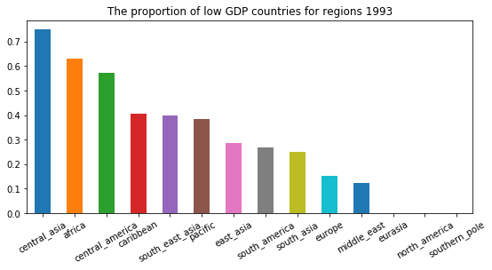

```python
dataset1993['region_o'].value_counts()
dataset_gdp1 = dataset1993[dataset1993['gdp_wdi_const_o']<12593054845.2028]
dataset_gdp1['region_o'].value_counts()#計算出實際GDP小於中位數的原始區域在資料集中出現的數量
lowgdp_proportion1993 = (dataset_gdp1['region_o'].value_counts())/(dataset1993['region_o'].value_counts())
#計算各區域在1993年低於全球GDP中位數的比例
lowgdp_proportion1993_sort = lowgdp_proportion1993.sort_values(ascending=False)#利用sort函數進行倒序排列
lowgdp_proportion1993_sort.plot.bar(title='The proportion of low GDP countries for regions 1993',figsize=(9,4),rot=30)#繪製柱狀圖
#中亞、非洲、中美洲、加勒比、東南亞、太平洋區域
```

```python
dataset2013 = dataset[dataset['year'] == 2013]
dataset2013['gdp_wdi_const_o'].median()
#取2013年所有原始國家實際GDP的中位數
```

```
26255973690.26945
```

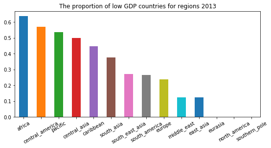

```python
#此處計算方式與上相同，為2013年相關數據
dataset2013['region_o'].value_counts()
dataset_gdp2 = dataset2013[dataset2013['gdp_wdi_const_o']<26255973690.26945]
dataset_gdp2['region_o'].value_counts()
lowgdp_proportion2013 = (dataset_gdp2['region_o'].value_counts())/(dataset2013['region_o'].value_counts())
lowgdp_proportion2013_sort = lowgdp_proportion2013.sort_values(ascending=False)
lowgdp_proportion2013_sort.plot.bar(title=('The proportion of low GDP countries for regions 2013'),rot=30,figsize=(9,4))
#非洲、中美洲、太平洋、中亞、加勒比、南亞區域
```

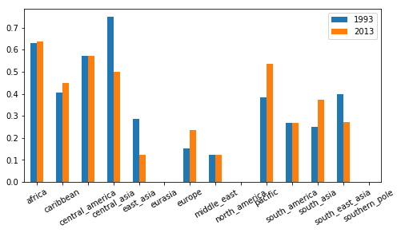

```python
lowgdp_com = pd.concat([lowgdp_proportion1993,lowgdp_proportion2013],axis=1)#合併1993年和2013年的dataframe
lowgdp_com.columns = ['1993','2013']#將欄位賦名
lowgdp_com.plot.bar(rot = 30,figsize = (8,4))#繪製柱狀圖
```

### 回答：二十年間的全球總體GDP總量形勢變化不大。按照區域內實際GDP低於中位數國家的佔比，一直相對落後的五個區域為：中亞、非洲、中美洲、加勒比、太平洋區域（低於實際GDP中位數的國家佔比一直超過30%）。另外，南亞和東南亞也相對落後。

### 從各區域看，亞洲除南亞外，在二十年間大幅降低了經濟不發達國家佔比；而加勒比、歐洲、太平洋、南亞則區域內經濟不發達國家佔比有所上升；其餘地區內佔比相對平穩。

### 3.屬於經濟較不發達的區域有哪些？(以人均GDP計算）

```python
#採gdp_wdi_cap_const_o變量，含義為人均實際國內生產總值，取1993年所有原始國家人均實際GDP的中位數
dataset1993_per = dataset[dataset['year'] == 1993]
dataset1993_per['gdp_wdi_cap_const_o'].median()
```

```
2804.46919442331
```

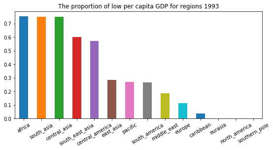

```python
dataset1993_per['region_o'].value_counts()
dataset_gdp3 = dataset1993_per[dataset1993_per['gdp_wdi_cap_const_o']<2804.46919442331]
dataset_gdp3['region_o'].value_counts()#計算出實際GDP小於中位數的原始區域在資料集中出現的數量
lowgdp_proportion1993_per = (dataset_gdp3['region_o'].value_counts())/(dataset1993_per['region_o'].value_counts())
#計算各區域在1993年低於全球GDP中位數的比例
lowgdp_proportion1993_sort_per = lowgdp_proportion1993_per.sort_values(ascending=False)#利用sort函數進行倒序排列
lowgdp_proportion1993_sort_per.plot.bar(title='The proportion of low per capita GDP for regions 1993',figsize=(9,4),rot=30)#繪製柱狀圖
```

```python
#取2013年所有原始國家人均實際GDP的中位數
dataset2013_per = dataset[dataset['year'] == 2013]
dataset2013_per['gdp_wdi_cap_const_o'].median()
```

```
5696.202712408036
```

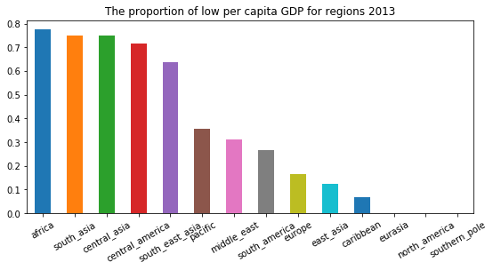

```python
dataset2013_per['region_o'].value_counts()
dataset_gdp4 = dataset2013_per[dataset2013_per['gdp_wdi_cap_const_o']<5696.202712408036]
dataset_gdp4['region_o'].value_counts()#計算出實際GDP小於中位數的原始區域在資料集中出現的數量
lowgdp_proportion2013_per = (dataset_gdp4['region_o'].value_counts())/(dataset2013_per['region_o'].value_counts())
#計算各區域在1993年低於全球GDP中位數的比例
lowgdp_proportion2013_sort_per = lowgdp_proportion2013_per.sort_values(ascending=False)#利用sort函數進行倒序排列
lowgdp_proportion2013_sort_per.plot.bar(title='The proportion of low per capita GDP for regions 2013',figsize=(9,4),rot=30)#繪製柱狀圖
```

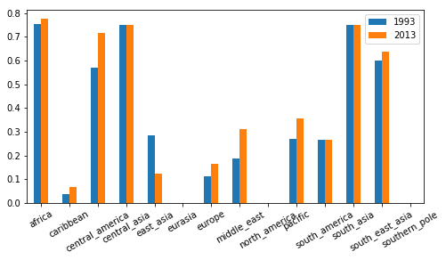

```python
lowgdp_com_per = pd.concat([lowgdp_proportion1993_per,lowgdp_proportion2013_per],axis=1)#合併1993年和2013年的dataframe
lowgdp_com_per.columns = ['1993','2013']#將欄位賦名
lowgdp_com_per.plot.bar(rot = 30,figsize = (8,4))#繪製柱狀圖
```

### 回答：根據人均實際GDP低於中位數的國家佔比，非洲、中美洲、中亞、南亞和東南亞五個區域明顯落後於其餘地區。

### 參考上述各區域的實際GDP與人均實際GDP後，屬於經濟不發達的地區有：非洲、中美洲、加勒比、太平洋區域及中亞、南亞和東南亞區域。

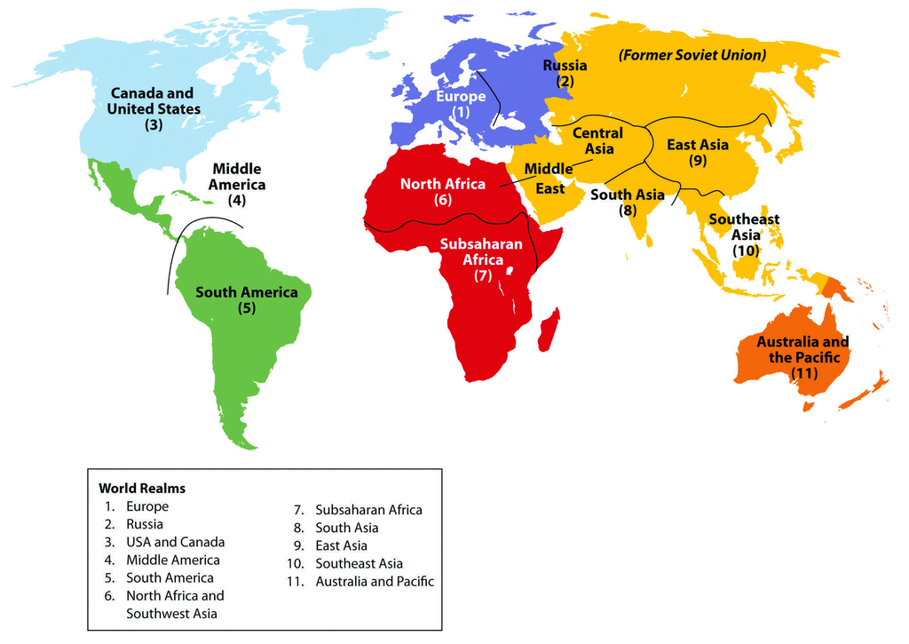

```python
from IPython.display import Image
Image(filename='world regions.jpg',width=800,height=800)
```

### 4.各國的人口與GDP是否存在相關性？經緯度與GDP是否存在相關性？

```python
#取資料集中的gdp_wdi_const_o欄位（真實gdp）和人口數量欄位，並建立新的資料集
pop_gdp = dataset[['pop_o','gdp_wdi_const_o']]
pop_gdp.corr()#計算相關係數
```

|  | pop_o | gdp_wdi_const_o |
| --- | --- | --- |
| pop_o | 1.000000 | 0.387622 |
| gdp_wdi_const_o | 0.387622 | 1.000000 |

```python
pop_gdp_per = dataset[['pop_o','gdp_wdi_cap_const_o']]#取人均真實GDP欄位
pop_gdp_per.corr()
```

|  | pop_o | gdp_wdi_cap_const_o |
| --- | --- | --- |
| pop_o | 1.000000 | -0.056765 |
| gdp_wdi_cap_const_o | -0.056765 | 1.000000 |

```python
lat_gdp = dataset[['lat_o','gdp_wdi_const_o']]
lat_gdp.corr()
```

|  | lat_o | gdp_wdi_const_o |
| --- | --- | --- |
| lat_o | 1.000000 | 0.171095 |
| gdp_wdi_const_o | 0.171095 | 1.000000 |

```python
lng_gdp = dataset[['lng_o','gdp_wdi_const_o']]
lng_gdp.corr()
```

|  | lng_o | gdp_wdi_const_o |
| --- | --- | --- |
| lng_o | 1.000000 | -0.051397 |
| gdp_wdi_const_o | -0.051397 | 1.000000 |

### 回答：人口與GDP總量呈中度正相關，與人均GDP幾乎無相關性。

### 緯度與GDP總量呈弱正相關，與經度幾乎無相關性。

### 5.屬於政治穩定度低的區域有哪些？其與經濟發展相對落後的區域是否有所關聯？

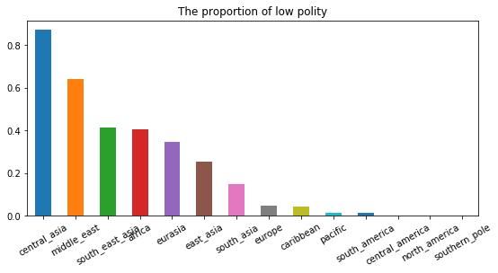

```python
#採polity_o變量，含義為政治穩定度，取值為[-10,10]，數值越小越不穩定
dataset_polity_low1 = dataset[dataset['polity_o'] < 0] #政治穩定值小於0
lowpolity_proportion = dataset_polity_low1['region_o'].value_counts()/dataset['region_o'].value_counts()#計算低政治穩定國家佔各自區域的比重
lowpolity_proportion.sort_values(ascending=False).plot.bar(title='The proportion of low polity',rot=30,figsize=(9,4))#將上述dataframe通過sort函數做倒序排列，並繪製柱狀圖
#可見政治不穩定國家佔比最高的區域前几位為：中亞、中東、東南亞、非洲、歐亞大陸、東亞、南亞。
#其中，中東、東亞和歐亞大陸在上述計算中不屬於經濟相對落後區域。
```

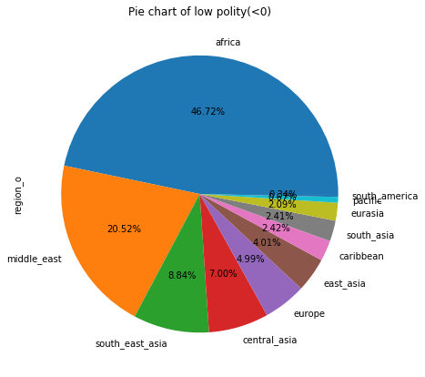

```python
dataset_polity_low1['region_o'].value_counts().plot.pie(title='Pie chart of low polity(<0)',figsize =(7,7),autopct='%1.2f%%')
#繪製餅狀圖，並標明佔比，按區域劃分
```

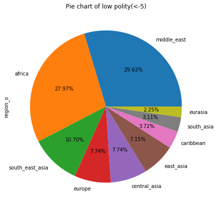

```python
dataset_polity_low2 = dataset[dataset['polity_o'] < -5]#政治穩定值小於-5
dataset_polity_low2['region_o'].value_counts().plot.pie(title='Pie chart of low polity(<-5)',figsize=(7,7),autopct='%1.2f%%')
#繪製餅狀圖，並標明佔比
```

### 答：政治不穩定國家在區域內佔比相對高的區域為中亞、中東、東南亞、非洲、歐亞大陸、東亞、南亞。在所有政治不穩定的國家中，中東和非洲的國家佔據了較多的比例。

### 根據上述計算，中東、東亞和歐亞大陸並不屬於經濟相對落後區域，而中亞、東南亞、非洲和南亞則屬於經濟相對落後區域。可見經濟相對落後和政治不穩定間存在一定關聯性，但並不絕對。

### 6.各區域曾遭受殖民統治的程度為何？其與上述經濟相對落後的區域是否存在關聯？

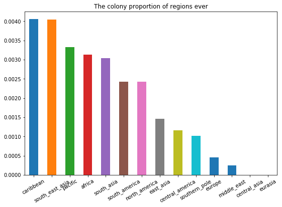

```python
dataset_colony = dataset[dataset['colony_of_destination_ever']==1]
colony_proportion = dataset_colony['region_o'].value_counts()/dataset['region_o'].value_counts()
colony_proportion.sort_values(ascending=False).plot.bar(title='The colony proportion of regions ever',rot=30,figsize=(9,6))
```

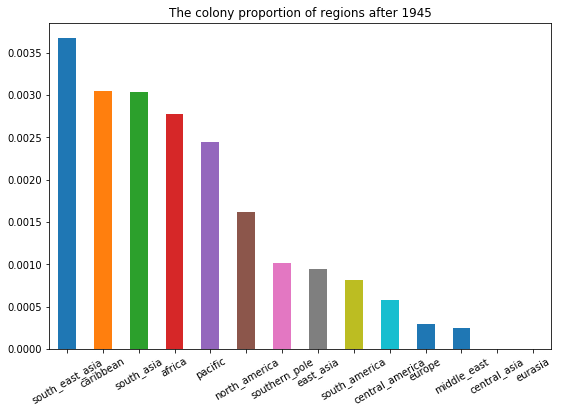

```python
dataset_colony_45 = dataset[dataset['colony_of_destination_after45']==1]
colony_proportion_45 = dataset_colony_45['region_o'].value_counts()/dataset['region_o'].value_counts()
colony_proportion_45.sort_values(ascending=False).plot.bar(title='The colony proportion of regions after 1945',rot=30,figsize=(9,6))
```

### 回答：曾受殖民程度最深和1945年後受殖民程度較深的的地區都為加勒比、東南亞、太平洋、非洲、南亞區域。而這五個區域在上述計算中，都屬於經濟相對落後的區域，可得出結論：曾遭受殖民的程度和經濟相對落後存在關聯性。

### 7.在經濟較不發達的区域，區域內國家與他國貿易合作的程度是否相對較低？

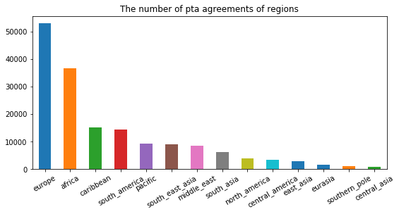

```python
#採agree_pta變量，含義為國家對至少在一個積極的優惠貿易協定中。
dataset_coop = dataset[dataset['agree_pta'] == 1]#取存在優惠貿易協定的國家對，並建立新的dataframe
dataset_coop['region_o'].value_counts().plot.bar(title='The number of pta agreements of regions',rot=30,figsize=(9,4))#繪製數量統計的柱狀圖
```

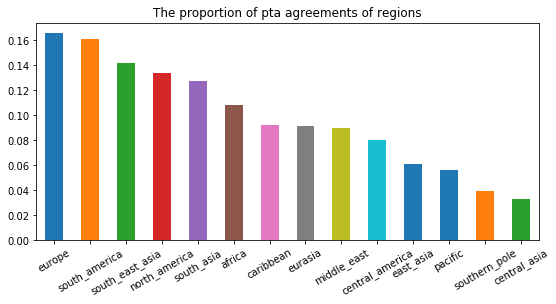

```python
pta_proportion = dataset_coop['region_o'].value_counts()/dataset['region_o'].value_counts()#計算具有優惠貿易協定的區域佔比（原始區域）
pta_proportion.sort_values(ascending=False).plot.bar(title='The proportion of pta agreements of regions',rot=30,figsize=(9,4))#繪製柱狀圖
```

### 綜上，區域經濟的較不發達和區域內國家與他國簽訂優惠貿易協定的程度無直接關聯。同樣不能被認定為因簽訂較少的貿易協定導致了經濟的落後。

### 8.各區域對外合作的主要目標區域是那些？

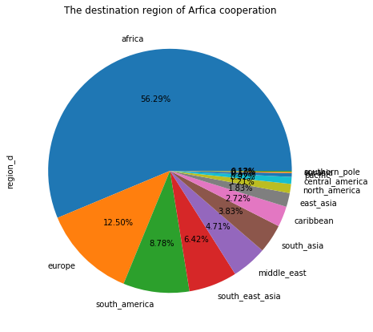

```python
Af_coop = dataset_coop[dataset_coop['region_o'] == 'africa']#在dataset_coop中取原始區域為非洲的資料並建立新的dataframe
Af_coop_region = Af_coop['region_d'].value_counts()#統計與非洲具有優惠貿易協定的區域數量
Af_coop_region.plot.pie(title= 'The destination region of Arfica cooperation',figsize=(7,7), autopct='%1.2f%%')#繪製餅狀圖
```

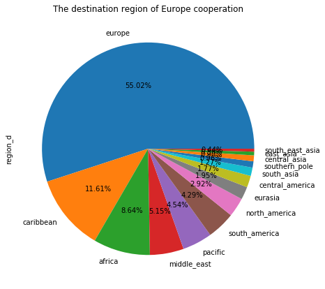

```python
EU_coop = dataset_coop[dataset_coop['region_o'] == 'europe']#在dataset_coop中取原始區域為歐洲的資料並建立新的dataframe
EU_coop_region = EU_coop['region_d'].value_counts()#統計與歐洲具有優惠貿易協定的區域數量
EU_coop_region.plot.pie(title='The destination region of Europe cooperation',figsize=(7,7), autopct='%1.2f%%')#作圓餅圖
```

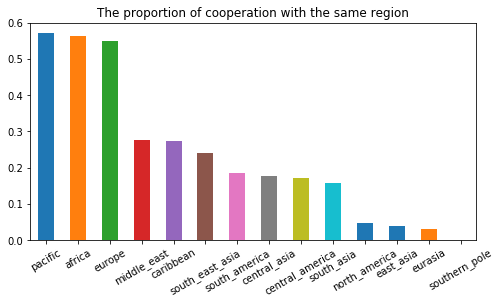

```python
same_region_coop = dataset_coop[dataset_coop['region_o']==dataset_coop['region_d']]
sameregion_proportion = same_region_coop['region_o'].value_counts()/dataset_coop['region_o'].value_counts()
sameregion_proportion.sort_values(ascending=False).plot.bar(rot=30,figsize=(8,4),title='The proportion of cooperation with the same region')
```

### 9.國家間的距離是否確實影響國家對外的貿易合作傾向？

```python
#此處採distance變量，含義為國家對之間的人口加權距離。
dataset_coop['distance'].value_counts(bins=10)#取dataset_coop中的distance欄位，並分為10組後加以計算次數
```

```
(-18.659000000000002, 1964.5]    49596
(1964.5, 3928.024]               35328
(7855.07, 9818.594]              19220
(5891.547, 7855.07]              14256
(3928.024, 5891.547]             12810
(9818.594, 11782.117]            10536
(11782.117, 13745.641]            8668
(15709.164, 17672.688]            6504
(13745.641, 15709.164]            5738
(17672.688, 19636.211]            2634
Name: distance, dtype: int64
```

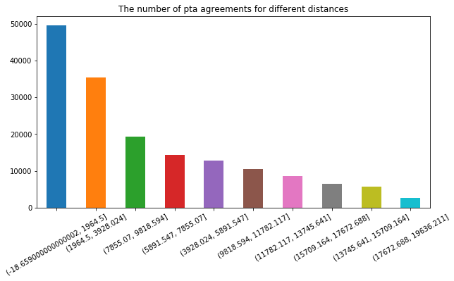

```python
dataset_coop['distance'].value_counts(bins=10).plot.bar(title='The number of pta agreements for different distances',rot=30,figsize=(10,5))
#繪製柱狀圖
```

### 回答：根據以上計算，國家確實傾向於同距離較近的國家簽署貿易協定，展開貿易合作。

### 10.牽涉在較多貿易制裁威脅的區域是哪些？其具有什麼特征？其與上述之分析是否有一定關聯性？

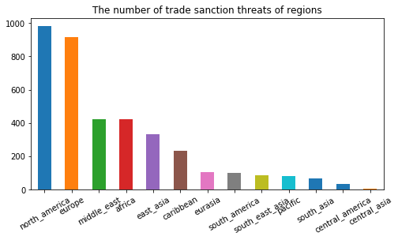

```python
#採sanction_threat_trade變量，含義為一個國家與另外一個國家之間存在着貿易制裁的威脅，1為有，0為無。
dataset_sanction = dataset[dataset['sanction_threat_trade']==1]#取資料集中存在着貿易制裁威脅的資料，並建立新的dataframe
dataset_sanction_region = dataset_sanction['region_o'].value_counts() + dataset_sanction['region_d'].value_counts()
#計算各區域涉及制裁威脅的數量
dataset_sanction_region.sort_values(ascending=False).plot.bar(title='The number of trade sanction threats of regions',rot=30,figsize=(8,4))
#倒序排列並繪製柱狀圖
```

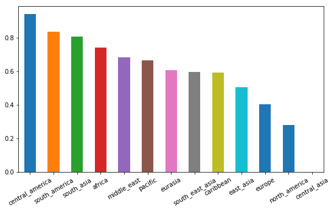

```python
NA_EU_sanction1 = dataset_sanction[(dataset_sanction['region_o']=='north_america')+(dataset_sanction['region_o']=='europe')]
NA_EU_sanction2 = dataset_sanction[(dataset_sanction['region_d']=='north_america')+(dataset_sanction['region_d']=='europe')]
#在存在貿易制裁威脅的資料集中，取涉及北美以及歐洲的資料並建立新的dataframe
(NA_EU_sanction2['region_o'].value_counts()+NA_EU_sanction1['region_d'].value_counts())#計算與歐洲和北美具有貿易制裁威脅的區域數量
sanction_NA_EU_proportion=(NA_EU_sanction2['region_o'].value_counts()+NA_EU_sanction1['region_d'].value_counts())/dataset_sanction_region
#計算與歐洲和北美具有貿易制裁威脅的區域數量在各區域貿易制裁威脅中的佔比並建立新的dataframe
sanction_NA_EU_proportion.sort_values(ascending=False).plot.bar(rot=30,figsize=(9,5))#繪製柱狀圖
```